# 7BBG1002: yeast sequence example, answers for teachers

Aleksej Zelezniak

2026-10-31

**For teachers only. Do not share with students.**

This document runs the whole practical from the raw data and answers every question of `rresearch_tutorial.Rmd`, including the homework. Knit it in the `yeast_project` folder (with `data/yeast_cds.fa.gz` and `data/yeast_genome.fa.gz`) in RStudio, after the `yeast-tools` Conda environment with SeqKit has been created. All numbers below come from Ensembl R64-1-1 (*S. cerevisiae*), the files the students download.

```r
library(tidyverse)
library(ggrepel)
# Same line as in the student notebook: lets bash chunks find seqkit
Sys.setenv(PATH = paste(path.expand("~/.conda/envs/yeast-tools/bin"),
                        Sys.getenv("PATH"), sep = ":"))
dir.create("results", showWarnings = FALSE)
```

# Exercise 1: Inspect the sequences

> How many sequence records are there? Why would counting all the lines give a different answer?

```bash
# Records: one header line (starting with >) per sequence
zcat data/yeast_cds.fa.gz | grep -c '^>'
# All lines: headers + sequence lines (each sequence is wrapped over many lines)
zcat data/yeast_cds.fa.gz | wc -l
```

```
## 6600
## 155818
```

**Answer.** 6,600 records. Counting all lines gives 155,818, because the sequence of each record is spread over many lines; only the header starts with `>`.

*Common mistake:* `grep -c '>'` without `^` gives the same number here, but would also count a `>` anywhere in a line.

# Exercise 2: Process the sequences with SeqKit

`-a` adds extra columns (quartiles, N50, GC) to the standard summary; the students run it without `-a`, which already gives min, average and max length.

```bash
seqkit stats -a data/yeast_cds.fa.gz data/yeast_genome.fa.gz 2>/dev/null
```

```
## file                     format  type  num_seqs     sum_len  min_len    avg_len    max_len       Q1       Q2       Q3  sum_gap      N50  N50_num  Q20(%)  Q30(%)  AvgQual  GC(%)  sum_n
## data/yeast_cds.fa.gz     FASTA   DNA      6,600   8,762,001       51    1,327.6     14,733      528    1,062    1,761        0    1,836      702       0       0        0  39.65      0
## data/yeast_genome.fa.gz  FASTA   DNA         17  12,157,105   85,779  715,123.8  1,531,933  439,888  745,751  948,066        0  924,431        6       0       0        0  38.15      0
```

The gene table, exactly as in the tutorial:

```bash
zcat data/yeast_cds.fa.gz | grep '>' > results/cds_headers.txt
cut -d ' ' -f 1,3 results/cds_headers.txt | sed -e 's/>//' -e 's/_mRNA//' -e 's/chromosome:R64-1-1://' -e 's/[ :]/\t/g' > results/positions.tsv
seqkit fx2tab -n -i -l data/yeast_cds.fa.gz > results/lengths.tsv
printf 'record_id\tchromosome\tstart\tend\tstrand\tlength_bp\n' > results/yeast_cds.tsv
paste results/positions.tsv results/lengths.tsv | cut -f 1-5,7 >> results/yeast_cds.tsv
head -n 3 results/yeast_cds.tsv
```

```
## record_id    chromosome  start   end strand  length_bp
## YPL071C  XVI 420048  420518  -1  471
## YLL050C  XII 39804   40414   -1  432
```

The same table with SeqKit only, and a check that both are identical:

```bash
printf 'record_id\tchromosome\tstart\tend\tstrand\tlength_bp\n' > results/yeast_cds_seqkit.tsv
seqkit replace -p '_mRNA cds chromosome:R64-1-1:(\S+) .*' -r ' $1' data/yeast_cds.fa.gz | seqkit fx2tab -n -l | tr ' :' '\t\t' >> results/yeast_cds_seqkit.tsv
diff results/yeast_cds.tsv results/yeast_cds_seqkit.tsv && echo "Both tables are the same"
```

```
## Both tables are the same
```

The chromosome table:

```bash
printf 'chromosome\tchromosome_bp\n' > results/chromosomes.tsv
zcat data/yeast_genome.fa.gz | grep '>' | cut -d ':' -f 4,6 | sed 's/:/\t/' >> results/chromosomes.tsv
cat results/chromosomes.tsv
```

```
## chromosome   chromosome_bp
## I    230218
## II   813184
## III  316620
## IV   1531933
## V    576874
## VI   270161
## VII  1090940
## VIII 562643
## IX   439888
## X    745751
## XI   666816
## XII  1078177
## XIII 924431
## XIV  784333
## XV   1091291
## XVI  948066
## Mito 85779
```

Header lengths next to the lengths counted by SeqKit. `diff` prints nothing if they agree:

```bash
tail -n +2 results/chromosomes.tsv > results/header_lengths.tsv
seqkit fx2tab -n -i -l data/yeast_genome.fa.gz | diff results/header_lengths.tsv - && echo "Header lengths agree with SeqKit"
```

```
## Header lengths agree with SeqKit
```

> How many genes and how many chromosomes are there? What are the shortest, longest and average CDS lengths? One “chromosome” is called `Mito`: what is it?

**Answer.** 6,600 genes (protein-coding CDS) on 17 sequences: 16 nuclear chromosomes (I–XVI) and `Mito`. CDS length: shortest 51 bp, longest 14,733 bp, average 1,327.6 bp. `Mito` is the **mitochondrial genome** (85,779 bp, 28 CDS), a separate small circular genome inside the mitochondria.

> Do the chromosome lengths in the headers agree with the lengths counted by SeqKit? Why is it worth checking?

**Answer.** Yes, all 17 agree. A header is just text written by someone; the sequence is the actual data. Checking catches truncated or corrupted downloads, edited or wrong headers, or a mix-up between genome versions. General lesson: verify metadata against the data whenever it is cheap.

# Exercise 3: Genes and chromosomes in R

```r
genes <- read_tsv("results/yeast_cds.tsv", show_col_types = FALSE)
nrow(genes)   # 6,600: same as the record count in Exercise 1
```

```
## [1] 6600
```

```r
genes_summary <- genes %>%
  summarise(genes = n(),
            mean_length = mean(length_bp),
            median_length = median(length_bp))
genes_summary
```

```
## # A tibble: 1 × 3
##   genes mean_length median_length
##   <int>       <dbl>         <dbl>
## 1  6600       1328.          1062
```

```r
write_tsv(genes_summary, "results/summary.tsv")

chromosomes <- read_tsv("results/chromosomes.tsv", show_col_types = FALSE) %>%
  left_join(count(genes, chromosome, name = "genes"), by = "chromosome") %>%
  mutate(genes_per_100kb = genes / chromosome_bp * 100000)
write_tsv(chromosomes, "results/chromosomes_genes.tsv")
```

> Are mean and median CDS length similar? What could explain a difference?

```r
summary(genes$length_bp)
```

```
##    Min. 1st Qu.  Median    Mean 3rd Qu.    Max.
##      51     528    1062    1328    1761   14733
```

**Answer.** Mean 1,328 bp, median 1,062 bp. The distribution is skewed to the right (see the histogram in Exercise 5): a few very long genes pull the mean up, while the median is robust to them.

> For most genes, `end - start + 1` equals `length_bp`, but not for all. Use `filter()` to find the genes where they differ. How many are there, and why is the gene longer on the chromosome than its CDS?

```r
spliced <- genes %>%
  filter(end - start + 1 != length_bp) %>%
  mutate(intron_bp = end - start + 1 - length_bp)   # extra length on the chromosome
nrow(spliced)
```

```
## [1] 287
```

```r
count(spliced, nuclear = chromosome != "Mito")
```

```
## # A tibble: 2 × 2
##   nuclear     n
##   <lgl>   <int>
## 1 FALSE      11
## 2 TRUE      276
```

```r
spliced %>% arrange(desc(intron_bp)) %>% head()
```

```
## # A tibble: 6 × 7
##   record_id chromosome start   end strand length_bp intron_bp
##   <chr>     <chr>      <dbl> <dbl>  <dbl>     <dbl>     <dbl>
## 1 Q0045     Mito       13818 26701      1      1605     11279
## 2 Q0070     Mito       13818 23167      1      1893      7457
## 3 Q0065     Mito       13818 21935      1      1671      6447
## 4 Q0105     Mito       36540 43647      1      1158      5950
## 5 Q0060     Mito       13818 19996      1      1248      4931
## 6 Q0120     Mito       36540 42251      1      1917      3795
```

**Answer.** 287 genes. The CDS contains only the coding exons; the chromosome coordinates span the whole gene, including the **introns** that are spliced out. 276 are nuclear genes (only ~5% of yeast genes have introns, usually one short one) and 11 are mitochondrial; the largest differences are mitochondrial genes such as COX1 (Q0045), which has many long introns. `end - start + 1` is never smaller than `length_bp`.

> Which chromosome has the most genes? Is it also the longest? Which chromosome has the highest and which the lowest gene density?

```r
chromosomes %>% arrange(desc(genes))
```

```
## # A tibble: 17 × 4
##    chromosome chromosome_bp genes genes_per_100kb
##    <chr>              <dbl> <int>           <dbl>
##  1 IV               1531933   836            54.6
##  2 XV               1091291   597            54.7
##  3 VII              1090940   583            53.4
##  4 XII              1078177   578            53.6
##  5 XVI               948066   511            53.9
##  6 XIII              924431   505            54.6
##  7 II                813184   456            56.1
##  8 XIV               784333   435            55.5
##  9 X                 745751   398            53.4
## 10 XI                666816   348            52.2
## 11 V                 576874   323            56.0
## 12 VIII              562643   321            57.1
## 13 IX                439888   241            54.8
## 14 III               316620   184            58.1
## 15 VI                270161   139            51.5
## 16 I                 230218   117            50.8
## 17 Mito               85779    28            32.6
```

```r
chromosomes %>% arrange(desc(genes_per_100kb))
```

```
## # A tibble: 17 × 4
##    chromosome chromosome_bp genes genes_per_100kb
##    <chr>              <dbl> <int>           <dbl>
##  1 III               316620   184            58.1
##  2 VIII              562643   321            57.1
##  3 II                813184   456            56.1
##  4 V                 576874   323            56.0
##  5 XIV               784333   435            55.5
##  6 IX                439888   241            54.8
##  7 XV               1091291   597            54.7
##  8 XIII              924431   505            54.6
##  9 IV               1531933   836            54.6
## 10 XVI               948066   511            53.9
## 11 XII              1078177   578            53.6
## 12 VII              1090940   583            53.4
## 13 X                 745751   398            53.4
## 14 XI                666816   348            52.2
## 15 VI                270161   139            51.5
## 16 I                 230218   117            50.8
## 17 Mito               85779    28            32.6
```

**Answer.** Chromosome IV has the most genes (836) and is also the longest (1.53 Mb). Highest density: III (58.1 genes per 100 kb). Lowest: `Mito` (32.6); among the nuclear chromosomes, I (50.8). The nuclear chromosomes are all very similar (51–58 per 100 kb).

> Change the example above to list the genes on `Mito`, from longest to shortest.

```r
genes %>%
  filter(chromosome == "Mito") %>%
  arrange(desc(length_bp))
```

```
## # A tibble: 28 × 6
##    record_id chromosome start   end strand length_bp
##    <chr>     <chr>      <dbl> <dbl>  <dbl>     <dbl>
##  1 Q0055     Mito       13818 18830      1      2565
##  2 Q0050     Mito       13818 16322      1      2505
##  3 Q0120     Mito       36540 42251      1      1917
##  4 Q0070     Mito       13818 23167      1      1893
##  5 Q0065     Mito       13818 21935      1      1671
##  6 Q0045     Mito       13818 26701      1      1605
##  7 Q0115     Mito       36540 40265      1      1554
##  8 Q0255     Mito       74495 75984      1      1419
##  9 Q0110     Mito       36540 38579      1      1272
## 10 Q0060     Mito       13818 19996      1      1248
## # ℹ 18 more rows
```

**Answer.** 28 genes; the longest is Q0055 (2,565 bp). Note several genes share the start 13818: these are COX1 and the intron-encoded ORFs (AI1–AI5) that start in COX1 exons.

# Exercise 4: Strands, gaps and overlaps

```r
count(genes, strand)
```

```
## # A tibble: 2 × 2
##   strand     n
##    <dbl> <int>
## 1     -1  3269
## 2      1  3331
```

```r
neighbours <- genes %>%
  arrange(chromosome, start) %>%
  group_by(chromosome) %>%
  mutate(left_neighbour = lag(record_id),   # added for the homework
         gap_bp = start - lag(end) - 1,
         orientation = case_when(lag(strand) == strand ~ "tandem",
                                 lag(strand) == -1 ~ "divergent",
                                 lag(strand) == 1 ~ "convergent")) %>%
  ungroup() %>%
  filter(!is.na(gap_bp))

orientation_summary <- neighbours %>%
  group_by(orientation) %>%
  summarise(pairs = n(),
            median_gap = median(gap_bp),
            overlapping = sum(gap_bp < 0))
orientation_summary
```

```
## # A tibble: 3 × 4
##   orientation pairs median_gap overlapping
##   <chr>       <int>      <dbl>       <int>
## 1 convergent   1802       206.         229
## 2 divergent    1798       379          302
## 3 tandem       2983       380          115
```

```r
write_tsv(orientation_summary, "results/orientations.tsv")
sum(neighbours$gap_bp < 0)
```

```
## [1] 646
```

> Are genes spread evenly over the two strands?

**Answer.** Yes, almost evenly: 3,331 on the + strand, 3,269 on the − strand (50.5% vs 49.5%).

> How many neighbouring genes overlap in total? Are overlapping genes mostly on the same strand or on opposite strands?

**Answer.** 646 pairs overlap. Most are on opposite strands (229 convergent + 302 divergent = 531); only 115 tandem pairs (same strand) overlap. Many overlaps are small ORFs (e.g. dubious ORFs, `-A` and `-B` genes) inside or across a larger gene.

> Which orientation has the longest gaps and which the shortest? Use the second scheme to explain why.

**Answer.** Shortest: convergent (median 206 bp). Longest: tandem (380 bp) and divergent (379 bp), about the same here, because divergent pairs overlap most often (302 negative gaps) and that pulls their median down. Without overlaps divergent is clearly longest (Exercise 5). A convergent gap holds only the two 3′ ends (terminators), no promoter. A tandem gap holds the promoter of one gene, and a divergent gap holds the promoters of both genes (often a shared bidirectional promoter), so they need more space. *Accept “divergent” as the longest, as long as the explanation uses promoters.*

# Exercise 5: Make figures with ggplot2

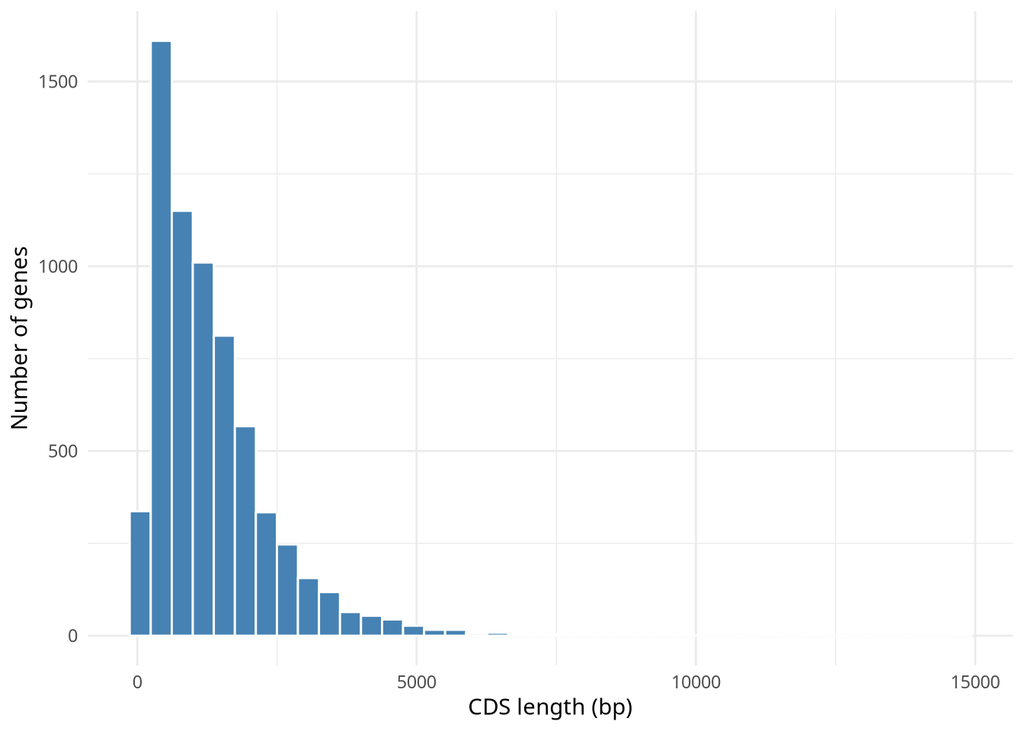

```r
p_length <- ggplot(genes, aes(x = length_bp)) +
  geom_histogram(bins = 40, fill = "steelblue", colour = "white") +
  labs(x = "CDS length (bp)", y = "Number of genes") +
  theme_minimal()
p_length
```

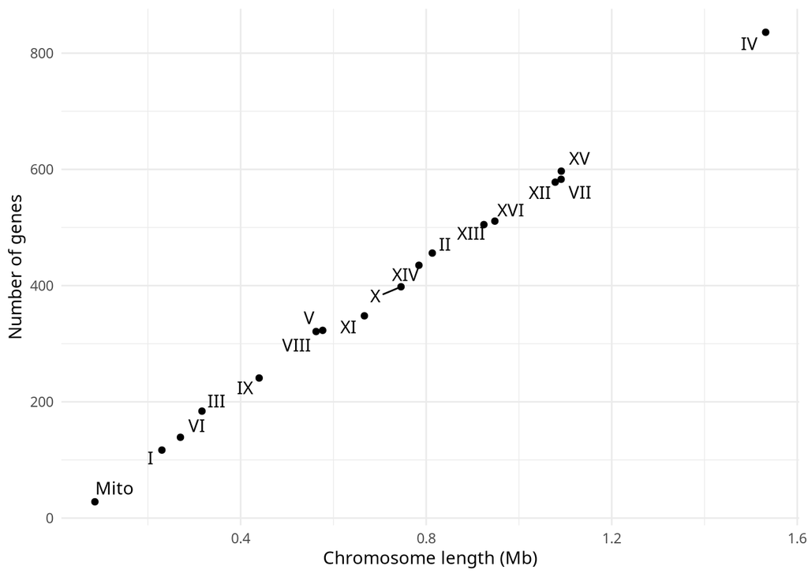

```r
p_chrom <- ggplot(chromosomes, aes(x = chromosome_bp / 1000000, y = genes,
                                   label = chromosome)) +
  geom_point() +
  geom_text_repel() +
  labs(x = "Chromosome length (Mb)", y = "Number of genes") +
  theme_minimal()
p_chrom
```

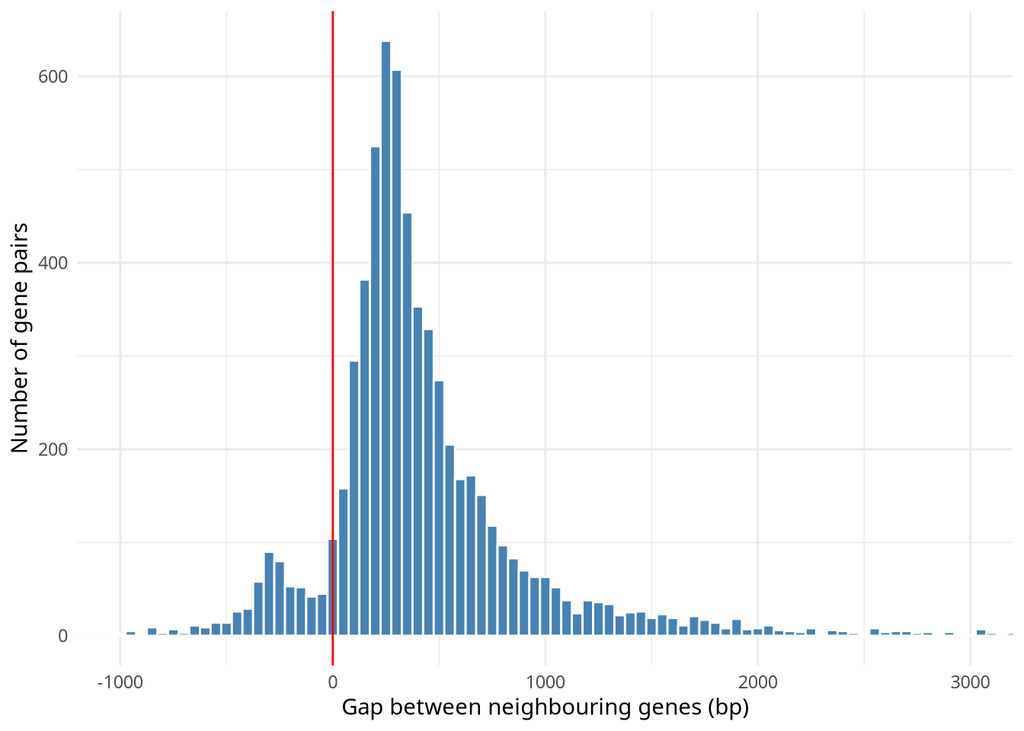

```r
p_gaps <- ggplot(neighbours, aes(x = gap_bp)) +
  geom_histogram(binwidth = 50, fill = "steelblue", colour = "white") +
  geom_vline(xintercept = 0, colour = "red") +
  coord_cartesian(xlim = c(-1000, 3000)) +
  labs(x = "Gap between neighbouring genes (bp)", y = "Number of gene pairs") +
  theme_minimal()
p_gaps
```

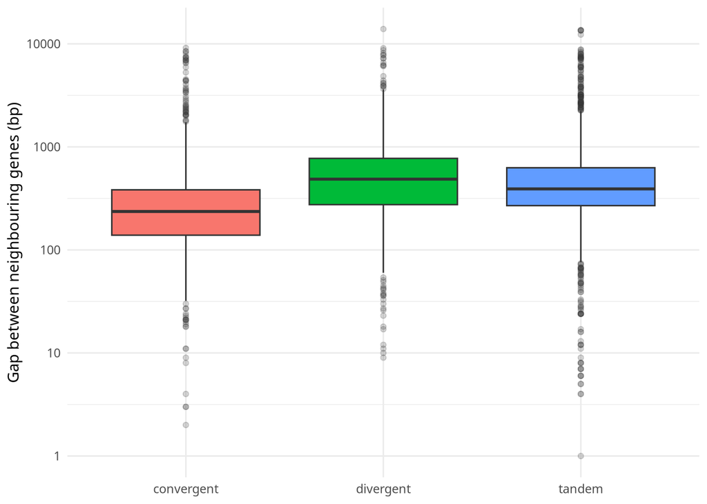

```r
p_orient <- ggplot(filter(neighbours, gap_bp > 0),
                   aes(x = orientation, y = gap_bp, fill = orientation)) +
  geom_boxplot(outlier.alpha = 0.2) +
  scale_y_log10() +
  labs(x = NULL, y = "Gap between neighbouring genes (bp)") +
  theme_minimal() +
  theme(legend.position = "none")
p_orient
```

> What relationship do you see between chromosome length and number of genes? Roughly how many genes are there per 100 kb? Which point does not follow the pattern, and why might that be?

```r
# Slope of the line through the nuclear chromosomes, as genes per 100 kb
fit <- lm(genes ~ chromosome_bp, data = filter(chromosomes, chromosome != "Mito"))
coef(fit)["chromosome_bp"] * 100000
```

```
## chromosome_bp
##      54.22648
```

```r
# Overall density
sum(chromosomes$genes) / sum(chromosomes$chromosome_bp) * 100000
```

```
## [1] 54.28924
```

**Answer.** An almost perfectly linear relationship: longer chromosomes have proportionally more genes, about 54 genes per 100 kb (one gene every ~1.8 kb). `Mito` lies below the line (32.6 per 100 kb): the mitochondrial genome is a separate genome with its own organisation, long introns, rRNA/tRNA genes (not in the CDS file) and long AT-rich non-coding regions. (Students may say “it is too small to see” - point them to the density table.)

> Make a bar plot of the gene density of each chromosome with `geom_col()` (x = `chromosome`, y = `genes_per_100kb`), and save it under a different file name.

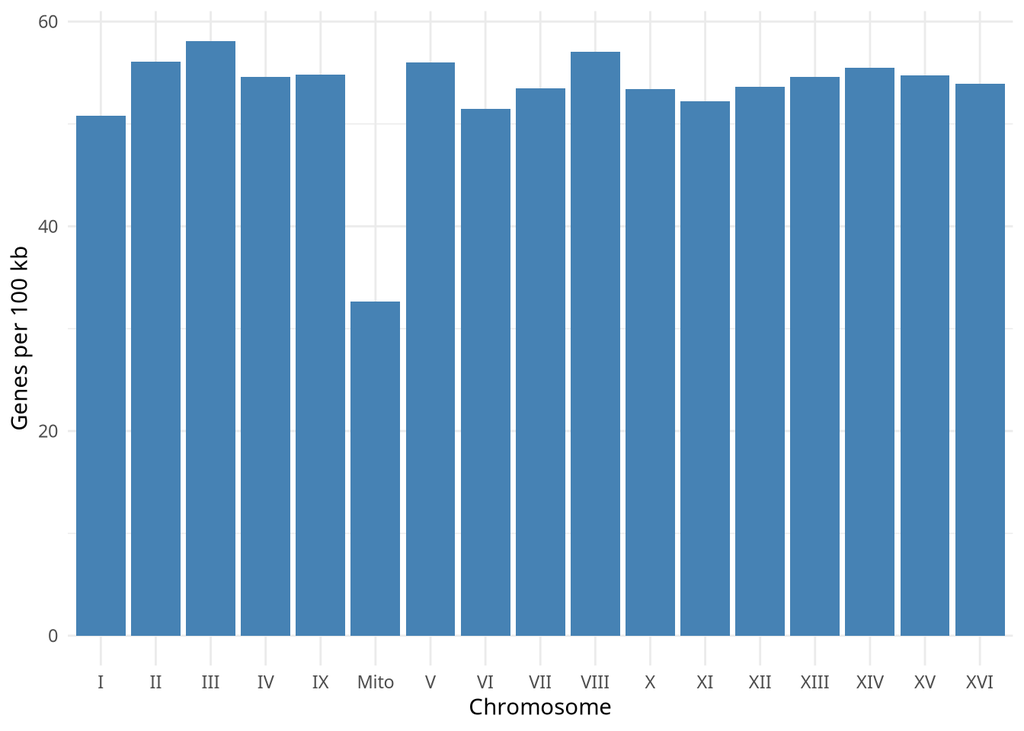

```r
p_density <- ggplot(chromosomes, aes(x = chromosome, y = genes_per_100kb)) +
  geom_col(fill = "steelblue") +
  labs(x = "Chromosome", y = "Genes per 100 kb") +
  theme_minimal()
p_density
```

```r
ggsave("results/gene_density.png", p_density, width = 8, height = 5)
```

*Optional improvement:* chromosomes are sorted alphabetically (I, II, III, IV, IX, …). `aes(x = factor(chromosome, levels = chromosomes$chromosome), ...)` keeps the file order.

> What is the most common gap size? Does the boxplot agree with your answer about orientations in Exercise 4?

```r
# Most common 50-bp bins of the gap histogram
neighbours %>%
  count(gap_bin = floor(gap_bp / 50) * 50) %>%
  arrange(desc(n)) %>%
  head(3)
```

```
## # A tibble: 3 × 2
##   gap_bin     n
##     <dbl> <int>
## 1     250   658
## 2     200   599
## 3     300   500
```

**Answer.** Around 200–300 bp (the highest bar is 250–300 bp): yeast genes are packed closely with short intergenic regions. Yes: the convergent box is clearly lowest, divergent and tandem higher, as in the medians from Exercise 4, and more clearly: without overlapping pairs the order is convergent < tandem < divergent (medians below), i.e. no promoter < one promoter < two promoters.

```r
neighbours %>%
  filter(gap_bp > 0) %>%
  group_by(orientation) %>%
  summarise(median_gap = median(gap_bp))
```

```
## # A tibble: 3 × 2
##   orientation median_gap
##   <chr>            <dbl>
## 1 convergent         236
## 2 divergent          486
## 3 tandem             391
```

> The human genome is about 3,100 Mb long and has about 20,000 protein-coding genes. Calculate its gene density in genes per 100 kb and compare it with yeast. What does this tell you about the human genome?

```r
human <- 20000 / 3100e6 * 100000
human
```

```
## [1] 0.6451613
```

```r
54.3 / human   # how many times denser yeast is
```

```
## [1] 84.165
```

**Answer.** About 0.65 genes per 100 kb, roughly 80 times lower than yeast (54). Only ~1–2% of the human genome codes for protein; the rest is large introns, long intergenic regions with regulatory elements, and repeats (transposons). Yeast has a compact genome with few, short introns.

# Finish: knit

> Which files would you give a classmate so they can repeat your work from scratch? Which files do they *not* need, because they can recreate them?

**Answer.** Needed: `rresearch_notebook.Rmd` (all code and text) and a description of the software (SeqKit 2.9.0 in the Conda environment, R and package versions from `sessionInfo()`, ideally an exported `environment.yml`). The data can be downloaded again with the commands in the notebook (give them the data too if the download link might change). Not needed: everything in `results/` and the knitted HTML - the notebook recreates them.

# Homework

**1. The ten longest genes.**

```r
longest <- genes %>%
  arrange(desc(length_bp)) %>%
  slice_head(n = 10)
longest
```

```
## # A tibble: 10 × 6
##    record_id chromosome   start     end strand length_bp
##    <chr>     <chr>        <dbl>   <dbl>  <dbl>     <dbl>
##  1 YLR106C   XII         349006  363738     -1     14733
##  2 YKR054C   XI          535647  547925     -1     12279
##  3 YHR099W   VIII        302761  313995      1     11235
##  4 YDR457W   IV         1369790 1379596      1      9807
##  5 YLL040C   XII          54211   63645     -1      9435
##  6 YBR140C   II          517350  526628     -1      9279
##  7 YOL081W   XV          171070  180309      1      9240
##  8 YLR087C   XII         306855  315731     -1      8877
##  9 YBL088C   II           51019   59382     -1      8364
## 10 YDR150W   IV          755628  763874      1      8247
```

```r
write_tsv(longest, "results/longest_genes.tsv")
count(longest, chromosome, sort = TRUE)
```

```
## # A tibble: 6 × 2
##   chromosome     n
##   <chr>      <int>
## 1 XII            3
## 2 II             2
## 3 IV             2
## 4 VIII           1
## 5 XI             1
## 6 XV             1
```

They are on XII (3 genes), II and IV (2 each), and XI, VIII and XV. The longest is YLR106C (MDN1, 14,733 bp), followed by YKR054C (DYN1, the dynein heavy chain). No pattern by chromosome: long genes are spread over the genome.

**2. Overlapping gene pairs.**

```r
overlaps <- neighbours %>% filter(gap_bp < 0)
count(overlaps, orientation)
```

```
## # A tibble: 3 × 2
##   orientation     n
##   <chr>       <int>
## 1 convergent    229
## 2 divergent     302
## 3 tandem        115
```

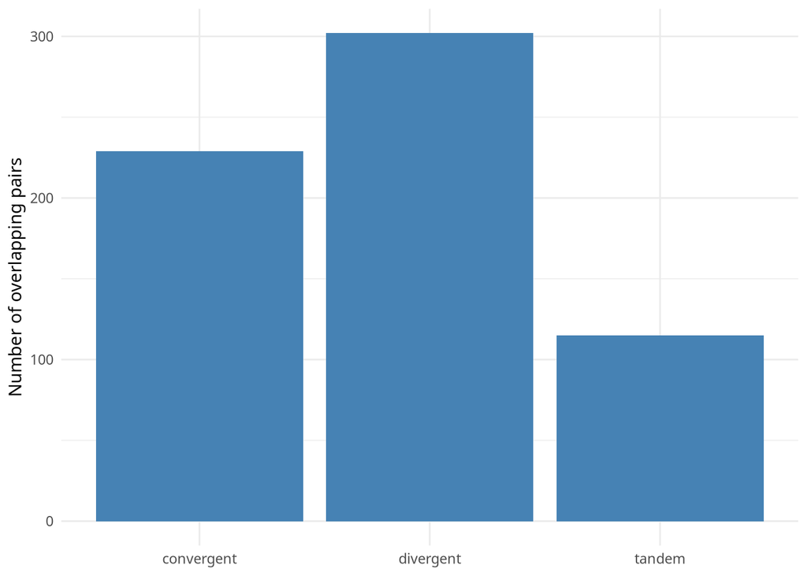

```r
p_overlap <- ggplot(overlaps, aes(x = orientation)) +
  geom_bar(fill = "steelblue") +
  labs(x = NULL, y = "Number of overlapping pairs") +
  theme_minimal()
p_overlap
```

```r
ggsave("results/overlaps.png", p_overlap, width = 6, height = 5)

# Largest overlaps, with both genes of the pair
overlaps %>%
  arrange(gap_bp) %>%
  select(left_neighbour, record_id, chromosome, gap_bp, orientation) %>%
  head(10)
```

```
## # A tibble: 10 × 5
##    left_neighbour record_id chromosome gap_bp orientation
##    <chr>          <chr>     <chr>       <dbl> <chr>
##  1 Q0070          Q0055     Mito        -9350 tandem
##  2 Q0065          Q0070     Mito        -8118 tandem
##  3 Q0105          Q0115     Mito        -7108 tandem
##  4 Q0060          Q0045     Mito        -6179 tandem
##  5 YNL339C        YNL339W-B XIV         -5365 divergent
##  6 YPL283C        YPL283W-B XVI         -5365 divergent
##  7 YIL177C        YIL177W-A IX          -5302 divergent
##  8 YJL225C        YJL225W-A X           -5302 divergent
##  9 Q0055          Q0050     Mito        -5013 tandem
## 10 YJR140C        YJR140W-A X           -4736 divergent
```

Divergent pairs overlap most often (302), then convergent (229), then tandem (115). On SGD, most overlapping genes turn out to be poorly characterised: many are *dubious ORFs* or small ORFs (names ending in `-A`/`-B`, e.g. YNL339W-B, YIL177W-A in subtelomeric regions), or intron-encoded ORFs in the mitochondrial genome. The point of the exercise: annotation includes uncertain genes, and overlaps often indicate them.

**3. Paragraph (example).** Yeast genes are densely packed, about 54 genes per 100 kb on all nuclear chromosomes, so gene number grows in proportion to chromosome length; the mitochondrial genome is less dense. Genes are spread evenly over both strands. Gaps between neighbours are short (typically 200–300 bp): convergent pairs, which share only terminators, have the shortest gaps, while divergent and tandem pairs, whose gaps contain promoters, have longer ones. About 10% of neighbouring pairs overlap, mostly on opposite strands. The human genome is ~80 times less dense, with most DNA non-coding. A pattern in a plot shows an association, not its cause: other variables (e.g. centromeres, repeats, annotation quality, how genes were predicted) can produce the same pattern, and testing a cause needs an experiment or a model that rules out alternatives.

[session information not shown]